# Darbas

Raminta Ramanauskaite

2019 m birželis 19 d

## R Markdown

Švietimas yra viena iš aktualiausių visuomenės gyvenimo sričių. Mūsų šalyje ši sritis susiduria su problemomis. Daugelis pastebi, kad vyrauja dideli mokinių pasiekimų skirtumai miestuose ir regionuose, mokytojai išreiškia nusivylimą mažais atlyginimais, taip pat ir prieš metus įvestu etatiniu apmokėjimu, valdžios institucijos atsigręžia į mokytojus klausdami dėl silpnų mokinių rezultatų. Už švietimo kokybę atsakingi asmenys gręžiojasi vieni į kitus ir ieško kaltų, kol situacija Lietuvoje nesikeičia ir švietimo kokybė, mokytojų bei mokinių padėtis negerėja. Taigi pradėkime nuo mokytojų problemų. Bene didžiausia problema, kurią jie kelia – atlyginimų dydis. 2016 metais išrinkus naują Lietuvos Respublikos Seimą buvo paruošta ir LR Vyriausybės programa (Seimas (2016)), kurioje vienas iš uždavinių – įvesti pedagoginiam personalui etatinį apmokėjimą. Visų pirma, svarbu išsiaiškinti, kuo ankstesnė mokytojų darbo apmokėjimo tvarka buvo bloga (Profesąjungos (2017)). Didžiausia problema – labai dideli įkainiai kontaktinėms valandoms bei mažas skaičius valandų pamokų pasiruošimui ir darbų vertinimui. Dėl tokios tvarkos labiausiai nukentėdavo pedagogai, dirbantys mažų miestelių ar kaimų mokyklose, kur neturėdavo daug kontaktinių valandų. Spręsti šioms problemoms buvo pasitelktas etatinis apmokėjimas. Anot buvusios LR Švietimo ir mokslo ministrės Jurgitos Petrauskienės, „pagrindinis etatinės mokytojų darbo apmokėjimo sistemos tikslas – užtikrinti aiškesnę etato struktūrą, suvokiant, kad mokytojų darbas yra ne vien tik pamokų vedimas, bet kartu ir pasirengimas joms bei kitos mokyklos bendruomenei naudingos veiklos“ (Židžiūnienė (2018)). Taip pat ji teigia, kad ši nauja tvarka gali padėti sukurti patrauklesnę darbo aplinką jauniems pedagogams ir užtikrinti teisingesnę darbo užmokesčio sistemą. Tad kuo naujas mokytojų darbo apmokėjimas skiriasi nuo senesnio? Anksčiau pedagogų atlyginimas labiausia priklausydavo nuo turimų kontaktinių valandų skaičiaus. Kontaktinės valandos – laikas, per kurį mokytojas tiesiogiai dirba su mokiniais (pamokos, papildomojo ugdymo pamokos, pamokos neformaliojo švietimo įstaigoje)( ŠMM (2011)). Vadinasi, kuo daugiau buvo turima pamokų, tuo didesnį atlyginimą buvo galima gauti. Ši tvarka ypač kenkdavo mažų miestelių ar kaimų mokytojams, kurie mokyklose tiesiog negalėdavo turėti didelio kontaktinio valandų skaičiaus ten, kur yra nedaug klasių, be to, tos klasės dažnu atveju taip pat nėra didelės, nuo to taip pat kentėdavo atlyginimo dydis. Tam tikrą atlyginimo dalį sudarydavo ir papildomos valandos – laikas, skirtas netiesioginiam darbui su mokiniais (pasirengimas pamokoms, sąsiuvinių (kontrolinių darbų) taisymas, vadovavimas klasei ir kt.). Laikas mokinių darbų tikrinimui buvo įvertintas maždaug 4 kartais mažesniu tarifu (priklauso nuo darbo stažo bei kvalifikacinio laipsnio) ir tokių valandų buvo skiriama vos keletas per savaitę. Vos kelios valandos buvo skirtos ir pasiruošimui pamokoms. Už visus kitus papildomus darbus (bendravimui bei bendradarbiavimui su tėvais, darbų planavimui, rūpinimusi mokyklos renginiais) buvo skiriamos 0,5 – 3,5 valandos per savaitę. Šis skaičius priklausydavo nuo mokyklos finansinių galimybių. Kas keitėsi po etatinio darbo modelio priėmimo? Visų pirma, atlyginimai nebepriklauso nuo kontaktinių valandų. Iš viso mokytojas per savaitę turi turėti 36 valandas (1512 valandų per metus) veiklos (tiek kontaktinės, tiek ne kontaktinės valandos). Mokytojai, dirbantys už 1 etatą, su didesniu nei 2 metai stažu per savaitę gali turėti daugiausia 21 kontaktinę valandą (ne daugiau kaip 60% viso etato). Pasiruošimui pamokoms bei vertinimui skiriamas valandų skaičius lygus 40-60% nuo kontaktinių valandų skaičiaus (priklauso nuo dėstomo dalyko). 2,5 valandos per savaitę (102 valandos per metus) vidutiniškai yra privalomai skirtos darbui įsitraukiant į mokyklos bendruomenės veiklą, darbą su tėvais. Iš viso tokių valandų gali būti 502 per metus, arba kitaip sakant – beveik trečdalis viso darbo valandų. Etatinis darbo apmokėjimas leido sukurti šiek tiek geresnes sąlygas pedagogams, neturintiems stažo. Jų kontaktinių valandų skaičius per savaitę negali viršyti 18 valandų (per metus 756) ir tai yra iki 50% etato. 55–80% nuo kontaktinių valandų yra skirta pasiruošimui pamokoms bei vertinimui (priklausomai nuo dėstomo dalyko). Pradedantiesiems pedagogams taip pat privalomos 102 valandos darbo, nesusijusio su pamokomis ar pasiruošimu joms, bet skiriamos mokyklos bendruomenės veiklai. Tokiam etatiniam apmokėjimui netrūko kritikos. Vienas iš aršiausių šios naujovės kritikų – aukščiausią reitingą Lietuvoje turinčios Vilniaus licėjaus gimnazijos direktorius Saulius Jurkevičius (Jurkevičius (2018)). Jis akcentuoja, jog yra neteisinga įkainoti vienodu tarifu pačias pamokas ir kitą veiklą, kitos veiklos aprašymai užims daug laiko, norint kelti atlyginimus juos reikėtų kelti atsižvelgiant į kontaktines valandas, reformos negalima įvesti birželio viduryje, nes trūks laiko bei kad lėšos naudojamos neišmintingai, dėl reformos nekils nei mokytojų algos nei bus pritrauktą jaunų mokytojų. Tad apie viską nuo pradžių. (ŠMM (2018))Turbūt tarifų suvienodinimu labiausiai džiaugiasi tie mokytojai, kurie turėjo nedidelį kontaktinių valandų skaičių. Taip, iš dalies tai naudinga ir reikalinga, bet ne visais atvejais. Pamokos išaiškinimas mokiniams ko gero yra tik mažesnioji pusė mokytojo įdėto darbo. Pamokoje matomas rezultatas būna nulemtas kiek laiko mokytojas ruošėsi pamokai dieną prieš jai įvykstant. Sudėtingiausia yra jaunų mokytojų situacija, todėl nieko nuostabaus, kad jiems suteikiama daugiau nekontaktinių valandų pasiruošti pamokai nei stažą turintiems mokytojams. Tarkime, ką tik studijas baigęs lietuvių kalbos mokytojas dirbantis gimnazijoje su 25 mokiniais kiekvienoje klasėje turi 17 kontaktinių valandų per savaitę, t.y. 3 klases. Per dieną būtų apie 3–4 pamokas. Jam priklausytų 13,6 valandos pasiruošimui pamokoms bei jų vertinimui per savaitę, o neskaičiuojant savaitgalių tai sudarytų 2,72 valandos per dieną (beveik 2 val. ir 45 min). Vienai pamokai pasiruošti per dieną tenka 41-55 minutės. Į šį laiką turėtų būti įskaičiuotas laikas pasiruošti teorinę medžiagą (gerai, jei pamoka skirta gramatikai, tam reikia mažiau laiko, o jeigu literatūrai – papasakoti apie autorių, jo kūrinį, istorinį/filosofinį/psichologinį/šių dienų kontekstą, ieškoti informacijos, naujų straipsnių, juos paruošti pamokai bei sukonspektuoti), užduotis, kurios padėtų mokiniams įtvirtinti žinias, įvertinti praeitos pamokos rašto darbus/testus/rašinius, rezultatus suvesti į dienyną. Jau nekalbant apie tai, kad geriausia neturėti dvyliktokų, nes jų rašiniai kai kada siekia 700 žodžių, visus ištaisyti ir parašyti kiekvienam komentarus užtruktų kelias valandas vienai klasei per dieną. O jei dar mokinių ruošimas meninio skaitymo konkursams, olimpiadoms…. Tada suprantama, kad toks laiko tarpas skirtas mokytojui yra tiesiog juokingai mažas, kaip ir apmokėjimas už tokį darbą. Tačiau yra ir kitas mokytojų tipas, na, tarkim, kūno kultūros. Jiems, kaip ir kitiems mokytojams priklauso valandos, skirtos pamokos pasiruošimui bei įvertinimui. Pradedantis mokytojas turi 17 kontaktinių valandų per savaitę. Jam priklausytų beveik 11 valandų per savaitę pamokų pasiruošimui bei vertinimui. Bet juk kūno kultūroj kontrolinių nėra. Ir testų nėra. Ir rašto darbų nėra (na, nebent labai jau reikia pasitaisyti pažymį pusmetyje, na tada kokie 3 per visą pusmetį ryžtasi tokiam žygdarbiui). Ir teorinės medžiagos ruošti nereikia. Na, programą reikia perskaityti. Tai čia kiek, 10 min.? Na gerai, pusvalandis. Na labai lėtai skaitant gal net valanda. Bet tai kur kitos 10 valandų per savaitę??? Taigi galima daryti išvadą, kad valandos, paskirstytos skirtingų disciplinų mokytojams nėra teisingos. Be to, nekontaktinėms valandoms priklauso ir bendruomeninė mokyklos veikla. Iki etatinio apmokėjimo darbuotojui galima buvo apmokėti iki 3,5 valandų per savaitę nekontaktinių valandų. Dabar tokia veikla gali apimti iki trečdalio etato. Tačiau juk pagrindinis mokytojo tikslas – mokyti vaikus, ugdyti jaunąją Lietuvos kartą. Šiuo atveju galima teigti, kad 30% savo darbo laiko mokytojas telkiasi ne į ugdymo procesą, o į šalutinius dalykus, tokius, kaip mokyklos renginių organizavimas, kurie nepadeda mokiniams tobulinti įgūdžių. Negana to, suskaičiuoti valandas, skirtas tokiai veiklai, kaip sakė S. Jurkevičius, yra sudėtinga ir tai labai smulkmeniškas darbas, atimantis daug laiko. Be to, tokį darbą sunku prižiūrėti, suskaičiuoti jam tenkantį laiką, tad tenka pasitikėti darbuotojo žodžiu. Bet tokiomis iniciatyvomis vis dėlto galėtų užsiimti tie mokytojai, kurių laikas skiriamas pamokų pasiruošimui bei rezultatų vertinimui nėra didelis (menų disciplinos, kūno kultūra). Etatinis darbo modelis buvo priimtas 2018 metų Seimo vasaros sesijos pačioje pabaigoje – birželio 29 d. Nuo šios dienos buvo likę kiek daugiau nei du mėnesiai iki įstatymo įsigaliojimo pradžios. Prieš mokslo metų pradžią likus dviem savaitėms buvo skubama pasirašyti naujas darbo sutartis su pedagogais, daugelyje mokyklų kilo lengvas chaosas, mokyklų vadovai nebuvo perpratę atlyginimų perskaičiavimo bei etato sudarymo tvarkos. Mokytojams buvo kilę daug klausimų bei baimių, kad bus nesudarytas pilnas etatas, kad atlyginimai vis dėlto mažės. Tokiam svarbiam pertvarkymui, paaiškinimui, kas keisis ir kaip viskas bus ministerija tikrai galėjo skirti daugiau laiko. Kaip ir minėta, viena iš pagrindinių baimių buvo, kad atlyginimai nedidės. Vis dėlto jie padidėjo. GRAFIKAS

| Laikotarpis | Neto atlyginimas |
| --- | --- |
| 2015K1 | 598.6 |
| 2015K2 | 610.3 |
| 2015K3 | 632.5 |
| 2015K4 | 634.3 |
| 2016K1 | 634.9 |
| 2016K2 | 648.9 |
| 2016K3 | 649.8 |
| 2016K4 | 685.9 |
| 2017K1 | 685.1 |
| 2017K2 | 689.9 |
| 2017K3 | 689.2 |
| 2017K4 | 747.0 |
| 2018K1 | 723.6 |
| 2018K2 | 730.1 |
| 2018K3 | 739.1 |
| 2018K4 | 843.5 |
| 2019K1 | 857.0 |

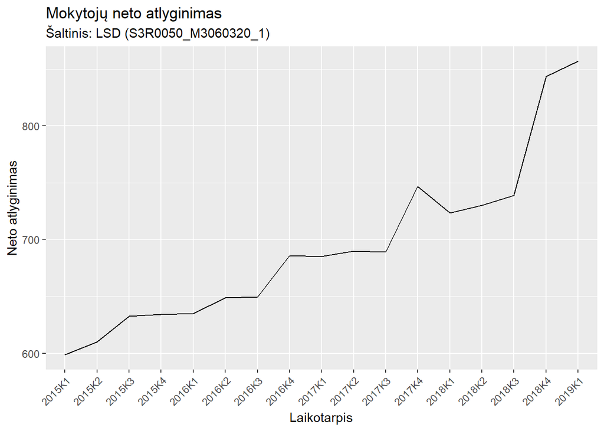

Etatinis apmokėjimas įsigaliojo nuo rugsėjo 1 d., tai atlyginimų pokytį parodo 2018 metų ketvirto ketvirčio duomenys. Atlyginimai atskaičius mokesčius palyginus su metų pradžia kilo 16,6%. 2019 metų pirmą ketvirtį neto atlyginimas dar šiek tiek paaugo. Tada kyla klausimas, ar šis kilimas nebuvo nulemtas mokytojų skaičiaus mažinimu? GRAFIKAS

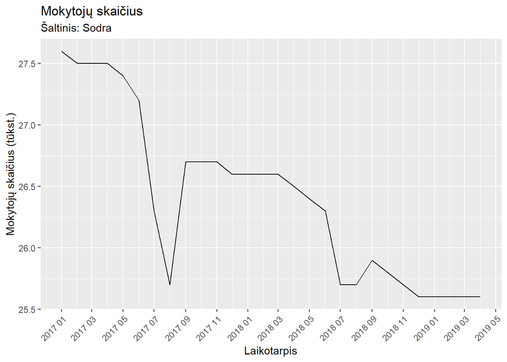

Nuo mokslo metų pabaigos iki naujų metų pradžios, kai įsigaliojo etatinis mokytojų apmokėjimas, iš darbo išėjo 400 mokytojų, kurie sudarė 1,5% nuo birželio mėnesį dirbančiųjų. Lygiai tokią pačią tendenciją buvo galima pastebėti ir 2017 metais, kai iš darbo išėjo 500 mokytojų, kurie sudarė 1,8% nuo dirbančių iki mokslo metų pabaigos. Vadinasi, mokytojų etatinis apmokėjimas vis dėlto pagerino mokytojų atlyginimus. Tačiau ne visiems. (Nagrockienė (2018)) Akivaizdu, kad labiausia atlyginimai kilo mažesnių mokyklų mokytojams, kurie anksčiau nesurinkdavo daug kontaktinių valandų, o po etatinio apmokėjimo etatą susirenka pasiimdami valandų už mokyklos bendruomeninę veiklą. Mažiausią atlyginimai kilo didesnių mokyklų, o ypač gimnazijų mokytojams, kuriems nebeliko 5–20% priedo. Kylantis mokytojų nepasitenkinimas privedė iki mėnesį laiko trukusio mokytojų streiko. (Antanavičius (2018)). Streiko metu buvo atstatydinta Švietimo ir mokslo ministrė Jurgita Petrauskienė. Po šio įvykio pavyko ministerijai ir profsąjungoms rasti kompromisinį variantą: buvo paskirti 185 milijonai eurų švietimui, nors valdžia buvo paskaičiavusi, kad profsąjungos reikalavimams įvykdyti reikės 300 milijonų eurų. Taigi kur nueina pinigai, skirti švietimui? Pagal 2016 metų duomenis Lietuva viršijo ES vidurkį švietimo reikmėms skaičiuojant pagal proc. nuo BVP. Lietuva skyrė 5,2% nuo BVP, kai ES vidurkis – 4,7% (Komisija (2018)). Žinoma, Skandinavijos šalys skiria dar daugiau lėšų švietimui (Komisija (2018)). Švedija, Suomija, Danija skiria nuo 6% iki 7% BVP. Tačiau pastebima, kad Lietuvoje lėšos panaudojamos neefektyviai. Viena iš neefektyvumo priežasčių – pastatų išlaikymas. Ir tai nieko nuostabaus, kai mokyklos yra nepilnos. Žurnale „Reitingai“ pateikiamas Gintaro Sarafino straipsnis „Turtingoji Lietuva: „auksiniai“ vaikai ir tūkstančiai už dvejetus“. Straipsnio autoriaus pateikia paradoksalią (net keliomis prasmėmis) situaciją. Pirmiausia jis atkreipia dėmesį į tai, kad to pačio rajono mokyklos finansavimas vienam mokiniui per metus gali skirtis net kelis kartus. Bene didžiausias matomas skirtumas tarp Mažeikių rajono Šerkšnėnų mokyklos daugiafunkcinio centro, kuris vienam mokiniui skiria 1893 eurus per metus bei Mažeikių rajono Krakių pagrindinės mokyklos, skiriančios mokiniui po 7140 eurų per metus. Taigi šių mokyklų lėšos vienam mokiniui skiriasi 3,77 karto. Daugiausia lėšų mokiniui tenka Vilniaus rajono Sužionių pagrindinei mokyklai – 7263 eurai. Akivaizdu, kad tokios didelės sumos susidaro dėl to, kad mokinių mokyklose nedaug, tačiau daug finansų pareikalauja elektra, šildymas, skirtingų disciplinų mokytojų atlyginimai. Antras paradoksas – tose mokyklose, kur mokiniams skiriama per metus daugiausia lėšų, jie pasiekia vienų iš prasčiausių rezultatų. Vadinasi, į mažesnes rajono mokyklas sunku pritraukti kvalifikuotų bei motyvuotų specialistų. Yra savivaldybių, kurios pasiryžo tokią problemą spręsti. Kaip pavyzdys įvardijama Druskininkų savivaldybė, kuri optimizavo mokyklų tinklą. Druskininkų meras Ričardas Malinauskas (oh well) džiaugiasi to rezultatu, nes neliko pustuščių didelių mokyklų pastatų, kuriuos reikėtų šildyti, taip sutaupytos lėšos nukreipiamos kitur. Tiesa, jis pripažįsta, kad toks sprendimas iš pradžių sulaukė nepopuliarumo. Tiek tėvams, tiek mokiniams atrodo nepatraukli mintis, kad šalia buvusi mokykla užsidaro, o vietoj jos laukia važiavimas į toliau esančią mokyklą geltonuoju autobusiuku. Tačiau, anot mero, po kurio laiko tėvai džiaugiasi, nes jų vaikai gauna geresnes sąlygas mokytis. Žinoma, tai nereiškia, kad visas mažesnes mokyklas reikia staiga imti ir uždaryti. Tiek vaikams, tiek jų tėvams būtų patogiausia, jeigu pradinės mokyklos būtų šalia jų gyvenamos vietos (bet juk tai galėtų būti ir kitų mokyklų skyriai, taip būtų sutaupoma išlaidų, kurios būtų skirtos administracijai). Išskirtinai mažas pradines mokyklas būtų galima uždaryti tik tuo atveju, jeigu savivaldybė užtikrintų patogų moksleivių nuvežimą/parvežimą iš mokyklos su geltonaisiais autobusiukais, ypač ten, kur retai važinėja viešasis transportas, taip nesukeliant nei tėvams, nei vaikams papildomų rūpesčių, o ir didesnė tikimybė būtų gauti geresnį išsilavinimą. Nors Lietuva skiria didesnį nei ES vidurkis finansavimą pagal procentus nuo BVP, vis dėlto Lietuvos rezultatai tarptautiniu mastu neatrodo labai gerai. 2015 metais atliktas tarptautinis penkiolikmečių tyras PISA parodo, kad Lietuva tarp visų EBPO šalių rikiuojasi apie vidurį. Na štai iš gamtamokslinio raštingumo Lietuva užima 36 vietą, šalia Islandijos, Kroatijos bei Italijos. Už jos iš ES šalių yra tik Malta, Graikija, Slovakija, Bulgarija bei Kipras. O mūsų kaimynai estai yra treti. Pagal skaitymo gebėjimus Lietuva yra 38, pasiekusi panašių rezultatų kaip Izraelis, Graikija ir Vengrija, už nugaros palikusi tik 7 kitas ES šalis. Pagal matematinį raštingumą Lietuva taip pat 36, palikdama už savęs taip pat 7 ES šalis. Na, o Suomija laikosi pirmame penketuke. Kur jos paslaptis? Iš tikrųjų ši šalis turi labai daug panašumų su Lietuva. Pamokos lygiai tiek pat trunka 45 minutes. Kaip bebūtų keista, ten daugiausia įtakos mokykloms turi vietinė valdžia. Ji taip pat sprendžia, kurią rugpjūčio savaitę prasidės mokslo metai (tai priklauso nuo tos vietovės klimato). Pasidomėjus darosi akivaizdu, LR Švietimo ir mokslo ministerija visais būdais stengiasi neatsilikti nuo Suomijos. Ministro įsakymo net buvo prailginti mokslo metai Lietuvoje Ir iš tikrųjų, Suomijoje mokslo metai baigiasi paskutinėmis gegužės ar pirmomis birželio dienomis. Iš viso Suomijos vaikai turi 10–11 vasaros atostogų savaičių ir dar maždaug 6 savaites atostogų mokslo metų eigos metu. Lietuvoje šie mokslo metai baigiasi prieš pat Jonines, taigi vasaros atostogų trukmė taip pat bus apie 10 savaičių. Lietuviai dar turi 5 savaites atostogų mokslo metų metu ir dar gali pakliūti 3 valstybinių švenčių dienos. Ir iš tikrųjų toks dirbtinis panašumas jau daugiau negu bado akis. Lietuvoje per papildomai pridėtas mokslo metų savaites mokiniai arba praktiškai nieko neveikia (tarkim žiūri jų išsirinktus filmus), arba jau nebeina į mokyklą, ką galima būtų pavadinti savivale, o vyresni mokiniai pradeda vasaros darbus ir tik mažumoje mokyklų vyksta mokymosi procesas. Tiesa, ministerija nepamiršo pasirūpinti mokinių mokslo metų ilgumu, bet pamiršo vieną paprastą dalyką – dauguma Lietuvos mokyklų yra seno statymo ir neturi kondicionierių. Mažiausiai antrus metus nuo pavasario pabaigos iki pat mokslo metų pabaigos Lietuvą „užgriūna“ dideli karščiai. Pietiniuose kabinetuose karštis siekia 38 laipsnius karščio. Ministerija į tai atsako, kad organizuokit veiklą lauke (na žinoma, nes ten vėsiau, kokie 35 laipsniai karščio). Galų gale mokyklos trumpino pamokų laiką, o tai realiai reiškia, kad į ją eiti net neapsimoka (ypač tiems, kurie gyvena toliau nuo mokyklos, nes jų kelionės į mokyklą laikas tampa beveik lygus bendram pamokų laikui tą dieną). O be to, tai gali netgi pakenkti sveikatai, ypač jeigu važiuojama neatnaujintu viešuoju transportu, o nuo stotelės iki namų tenka paėjėti nei daug nei mažai – kelis kilometrus – vidudienį per patį didžiausią karštį (asmeninė patirtis). EBPO pastebi, kad suomiai vaikus išleidžia bene vėliausiai – 7 metų. Ir jų mokymosi trukmė per metus yra viena trumpiausių (tiek mokslo metų trukmė, tiek pamokų kiekis per savaitę). Suomija dar pasižymi įdomiu dalyku – jie daugiausia iš visų vidurinio ugdymo pakopų laiko skiria pradiniam ugdymui (OECD (2018)). Jam per savaitę skiriama vidutiniškai 18–19 valandų. Pagrindiniam ugdymui skiriama (5–8 klasės) 16–17 valandų, o vyresniems mokiniams tenka apie 16 valandų. Lietuvoje analogiškai skiriama 23, 28 bei nuo 28 iki 35 pamokų per savaitę (nuoroda [https://www.smm.lt/uploads/documents/svietimas_pagrindinis_ugdymas_spec/BUP%20%C4%AEsakymas%202017-2019%20m.pdf]). Lietuvoje pastaruosius kelerius metus ne tik dvyliktokai laiko egzaminus, bet ir ketvirtokai, aštuntokai rašo standartizuotus testus. Suomijoje tokio dalyko nėra. Ir nesunku paaiškinti kodėl. Tokiu atveju mokytojas stengiasi išmokyti vaikus, kad jie išlaikytų testą, taigi jis ruošiamas būtent testo išlaikymui, o tai neturi prasmės, nes mokinys turi būti skatinamas individuliai mąstyti, o ne atlikti užduotis taip, kad įtiktų vertintojui. Pripažinkim, Lietuvoje su tuo yra didelė problema. Didžiausias iššūkis kiekvienam dvyliktokui – kaip išlaikyti lietuvių kalbos ir literatūros VBE. Realiai ketverius metus (nuo 9 klasės) mokiniai ruošiami rašyti ir mąstyti taip, kad įtiktų vertintojams, nors iš tikrųjų neįmanoma tiksliai pasakyti, o ką galvoje turėjo XX amžiaus rašytojas Antanas Škėma. Tačiau mokyklose mus to moko. Dar vienas svarbus dalykas, kad Suomijoje mokytojai turi turėti magistro laipsnį. Tai būtina, nes mokytojai turi ganėtinai daug laisvės ruošdami ugdymo programą (education (2018)). Mokytojo profesija Suomijoje yra ypač gerbiama, į ją sunku įstoti, tai byloja apie mokytojo profesijos prestižą, kas leidžia pritraukti tik labiausiai motyvuotus būsimus mokytojus. Suomijoje skiriama daug laiko kvalifikacijos kėlimo kursams. Lygiai to pačio reikėtų ir Lietuvoje, nes kai kurie mokytojai tikrai yra atsilikę su pamokų dėstymo naujovėmis, būdais, kuriuos galima pasitelkti sudominant mokinius pamokos medžiaga. Viena ne mažiau svarbi ypatybė Suomijos mokyklose, kad mokytojai tuos pačiu vaikus moko ne mažiau kaip šešerius metus. Ir atrodo, ar yra didelis skirtumas kiek laiko tas pats mokytojas moko vaikus? Ir vis dėlto yra. Tame pačiame žurnale „Reitingai“ yra 2019 metų gimnazijų reitingas. Šalia pateikiamos Lietuvos švietimo profesinės sąjungos vadovo Audriaus Jurgelevičiaus mintys, kad mokyklų tinklo pertvarka davė neigiamų rezultatų. Panaikinus daugumą vidurinių mokyklų mokiniams per visą mokymosi etapą tenka praeiti mažiausiai dvi arba netgi tris mokyklas (pradinę, progimnaziją (kartais šios dvi būna apjungtos) ir gimnaziją). Anot A. Jurgelevičiaus pirmasis pusmetis būna skirtas prisitaikyti prie mokytojų, naujos aplinkos bei klasės draugų, reikalavimų, mokyklos kultūros bei vertybių ir šis laikas moksleiviams būna sunkus, tad kenčia mokymosi rezultatai bei pats mokymasis nebėra toks produktyvus. Kaip viena iš tokios pertvarkos blogybių dar minima situacija, kai mokytojai nuleidžia rankas matydami nemotyvuotus mokinius, neranda priėjimo prie jų bei nesiekia įkvėpti mokytis ir tarsi nusimeta atsakomybę nuo savęs, nes juk mokinys vis tiek išeis iš šios mokyklos į kitą ir tegu kiti specialistai dirba. Kai mokinys išeina į kitą mokyklą dar nereikia jausti atsakomybė prieš savo kolegas, dirbančius toje pačioje mokykloje. Dar Lietuvos mokytojai yra per daug susitelkę į savo dalyką, kaip reikia „išeiti“ programą, o ne į asmeninius vaikų pasiekimus. Kai mokinys kažko neišmoksta ar prastai parašo kontrolinį tik vienetai mokytojų leidžia perrašyti darbą, visiems kitiems nelabai svarbu, kad su mokiniu reikia individualiai padirbėti tam, kad jis suprastų išdėstytą temą. Juk visada dalykai būna tarpusavyje susiję: neišmokę vieno mokiniai negebės suprasti kito, o taip ypač yra su disciplinomis, kurios mokiniams sekasi sunkiau – matematika, fizika, chemija. Kai kurie teigia, kad toks mokymo metodas stabdytų kitų vaikų ugdymo procesą. Bet laikas, skirtas mokiniams pakartoti, geriau suvokti temą, galėtų būti skirtas po pamokų. Tokiu atveju būtų išspręsta problema dėl korepetitorių: dabar jiems finansų negali skirti šeimos, neturinčios tam pinigų.

Sprendžiant visas problemas yra svarbiausia tartis su švietimo bendruomene ir kartu ieškoti palankiausių sprendimų, kurie padėtų mokiniams pasiekti kuo geresnių rezultatų. Siekiant išspręsti problemas gali ne viskas keistis į gerą, bus padaryta daug klaidų, svarbiausia nebijoti pripažinti jas padarius bei taisyti esamą situaciją, kai kada reikės imtis ir nepopuliarių sprendimų, svarbiausia, kad jie būtų tinkamai iškomunikuoti bendruomenei ir kad jai būtų pakankamai laiko naujoves suvokti bei jas priimti. Na ir pabaigai, giriama Suomijos švietimo sistema neatsirado per vieną dieną, jai reikėjo daug daugiau laiko, be to ši šalis neturėjo 50 metų trukusios sovietinės okupacijos. Tad galima tikėtis, kad po ilgesnio laiko tarpo Lietuvą taip pat kaip pavyzdį naudos kitos Europos bei pasaulio valstybės.

## Literatūra

Antanavičius, Ugnius. 2018. “15 Min Paaiškina: Kodėl Streikuoja Mokytojai Ir Ko Jie Reikalauja?” *„15min“*.

education, Finnish national agency for. 2018. “Teacher Education.”

Jurkevičius, Saulius. 2018. “Saulius Jurkevičius. Kodėl Būtina Sustabdyti Mokytojų Etatinio Apmokėjimo įvedimą?” *„Delfi“*.

Komisija, Europos. 2018. “Šalies Ataskaita. Lietuva 2019.”

Nagrockienė, Ingrida. 2018. “Pažadai Nesutilpo į Mokytojo Piniginę.” *„Sekundė“*.

OECD. 2018. “Education at a Glance. Finland.”

Profesąjungos. 2017. “Etatinio Darbo Apmokėjimas.”

Seimas, LR. 2016. “Nutarimas Dėl Lietuvos Respublikos Vyriausybės Programos.”

ŠMM. 2011. “Švietimo įstaigų Darbuotojų Ir Kitų įstaigų Pedagoginių Darbuotojų Darbo Apmokėjimo Tvarkos Aprašas.”

———. 2018. “Patobulintas Etatinio Apmokėjimo Modelis.”

Židžiūnienė, Aušra. 2018. “Etatinio Darbo Apmokėjimo Sėkmės Ir Nesėkmės….” *„Švietimo Naujienos“*.